# Week 2

Assistant Lecturer-A(Bondan and Kevin)

3/16/2021

# Bonjour! AED-A Class

## Dipelajari YA!!!

```r
getwd()
```

```
## [1] "C:/Users/bonda/OneDrive/Documents/MATKUL STATISTIK/Asdos AED Materi/Week 2"
```

```r
setwd("C:/Users/bonda/OneDrive/Documents/MATKUL STATISTIK/Asdos AED Materi/Week 2")
```

## Import Data

```r
dfMahasiswa <- read.csv("Jumlah Mahasiswa.csv", TRUE, sep = ",")
dfMahasiswa
```

```
##       Daerah Total.Mahasiswa
## 1 Wall Maria              45
## 2  Wall Sina              16
## 3  Wall Rose              13
## 4     Marley              15
## 5     Hizuru              11
```

# Learning Objective

1. Membuat Pie Chart Menggunakan pie()
2. Membuat Bar Plot Menggunakan barplot()
3. Membuat Histogram Menggunakan hist()
4. Membuat Stem and Leaf Menggunakan stem()

## 1. Pie Chart

In R the pie chart is created using the pie() function which takes positive numbers as a vector input. The additional parameters are used to control labels, color, title etc.

### Syntax

```
pie(x, labels, radius, main, col, clockwise)
```

Following is the description of the parameters used −

- x is a vector containing the numeric values used in the pie chart.
- labels is used to give description to the slices.
- radius indicates the radius of the circle of the pie chart.(value between −1 and +1).
- main indicates the title of the chart.
- col indicates the color palette.
- clockwise is a logical value indicating if the slices are drawn clockwise or anti clockwise.

### Simple Pie Chart

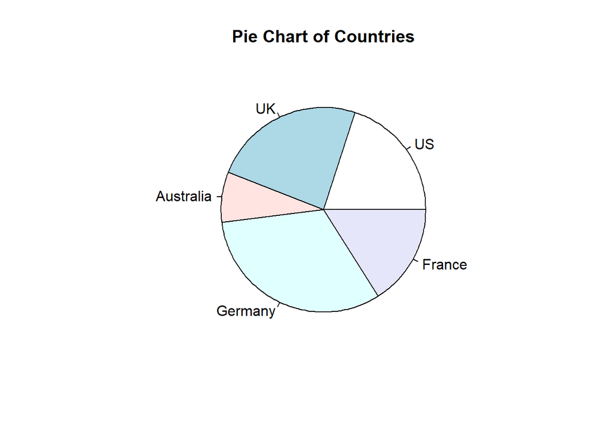

```r
slices <- c(10, 12,4, 16, 8)
lbls <- c("US", "UK", "Australia", "Germany", "France")
pie(slices, labels = lbls, main="Pie Chart of Countries")
```

**How To Set Specific Color in Pie Chart** I want to give colors to the piechart. I used. I want to give red color for apple, orange color for orange and blue color for grape etc. But my pie chart looks different.

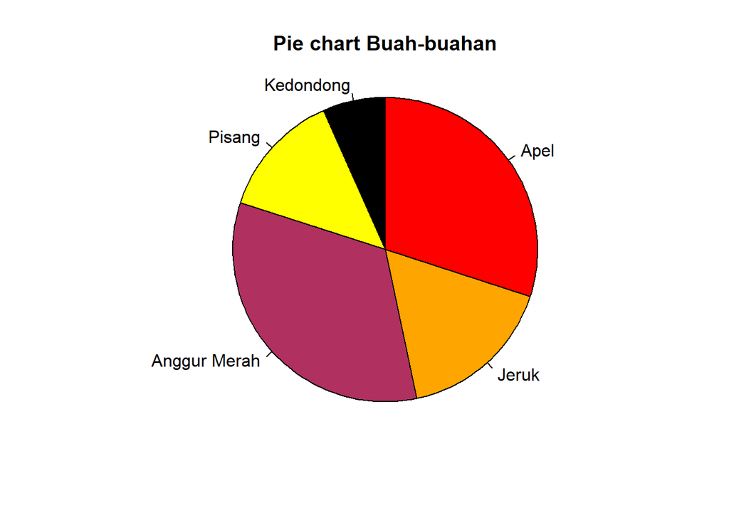

```r
buah <- c("Apel","Jeruk","Anggur Merah","Pisang","Kedondong")
vol <- c(90,50,100,40,20)
pie(x=vol, labels = buah, radius = 1,main = "Pie chart Buah-buahan", col=c("red","orange","maroon","yellow","black"),clockwise = T)
```

MengCustom Pie Chart dengan data Input

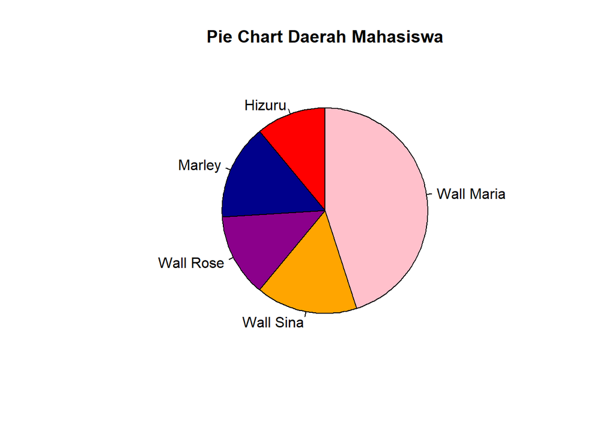

```r
pie(dfMahasiswa$Total.Mahasiswa,
    main = 'Pie Chart Daerah Mahasiswa',
    labels = dfMahasiswa$Daerah,
    radius = 0.8,
    clockwise = TRUE,
    col = c("pink","orange","darkmagenta","darkblue","red"))
```

MengCustom Pie Chart 2 dengan Data Input

- Tambahin Percentage and Legend

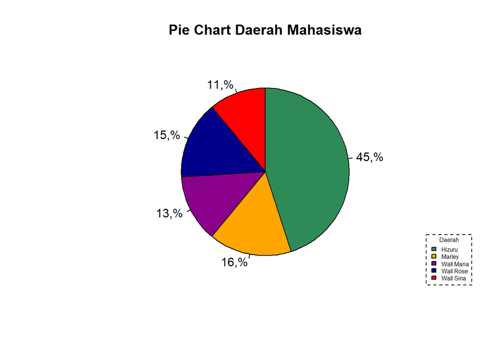

```r
percentage <- round(dfMahasiswa$Total.Mahasiswa/sum(dfMahasiswa$Total.Mahasiswa)*100, 2)
pie(dfMahasiswa$Total.Mahasiswa,
    main = 'Pie Chart Daerah Mahasiswa',
    labels = paste(percentage, '%', sep=","),
    radius = 0.8,
    clockwise = TRUE,
    col = c("seagreen","orange","darkmagenta","darkblue","red"))
legend('bottomright',
       legend = levels(as.factor(dfMahasiswa$Daerah)),
       fill = c("seagreen","orange","darkmagenta","darkblue","red"),
       title = "Daerah",
       box.lty = 2,
       cex = 0.5
       )
```

### Install plotrix package:

- Untuk Ini Masih Belum Bisa Di Print Di Markdown, Jadi Coba run Manual yahh…

```
install.packages("plotrix")
```

*Use pie3D()*

```
pie3D(dfMahasiswa$Total.Mahasiswa, labels = dfMahasiswa$Daerah, radius = 1,
      col = c("#E69F00","#999999", "#56B4E9", "darkred", "darkgreen"))
```

*Explode Pie Chartnya:*

```
# Explode the pie chart
pie3D(dfMahasiswa$Total.Mahasiswa, labels = dfMahasiswa$Daerah, radius = 1,
      col = c("#E69F00","#999999", "#56B4E9", "darkred", "darkgreen"),
      explode = 0.1)
```

## 2. Bar Plot

### Simple Bar Plot

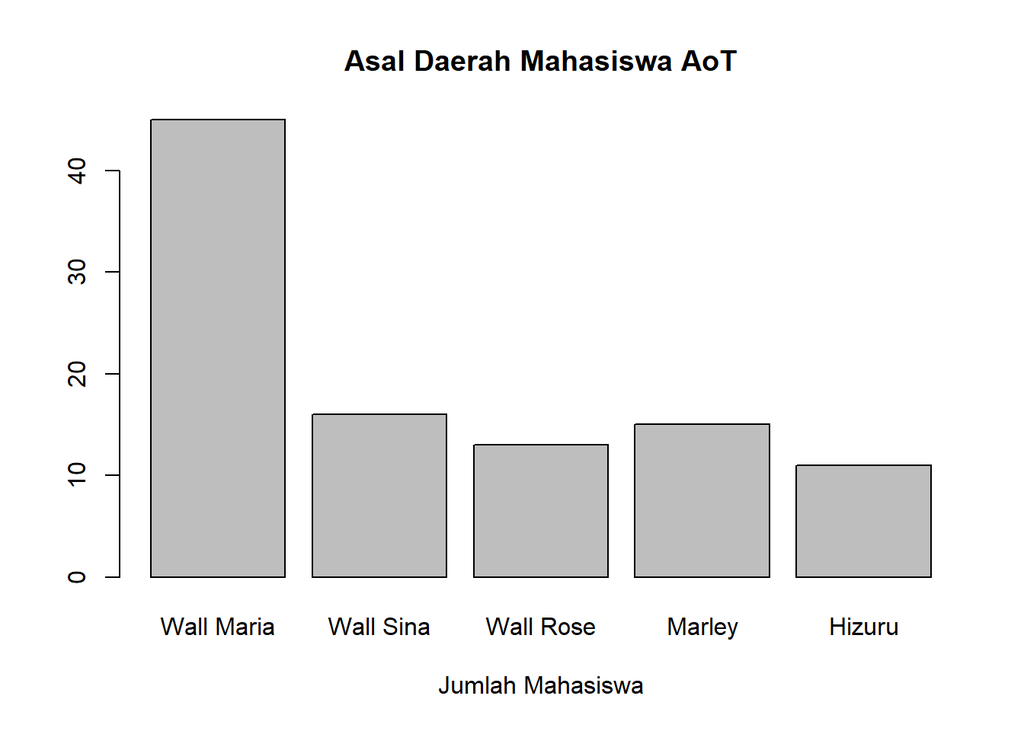

```r
barplot(dfMahasiswa$Total.Mahasiswa,
        main="Asal Daerah Mahasiswa AoT",
        xlab="Jumlah Mahasiswa",
        names = dfMahasiswa$Daerah)
```

### Horizontal Bar Plot

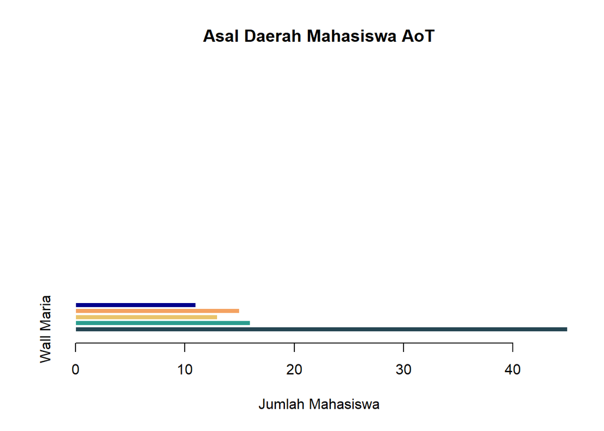

```r
barplot(dfMahasiswa$Total.Mahasiswa,
        main="Asal Daerah Mahasiswa AoT",
        horiz = TRUE,
        names = dfMahasiswa$Daerah,
        col = c("#264653","#2a9d8f","#e9c46a","#f4a261",'darkblue'),
        border = FALSE,
        ylim = range(0, 50),
        xlab="Jumlah Mahasiswa")
```

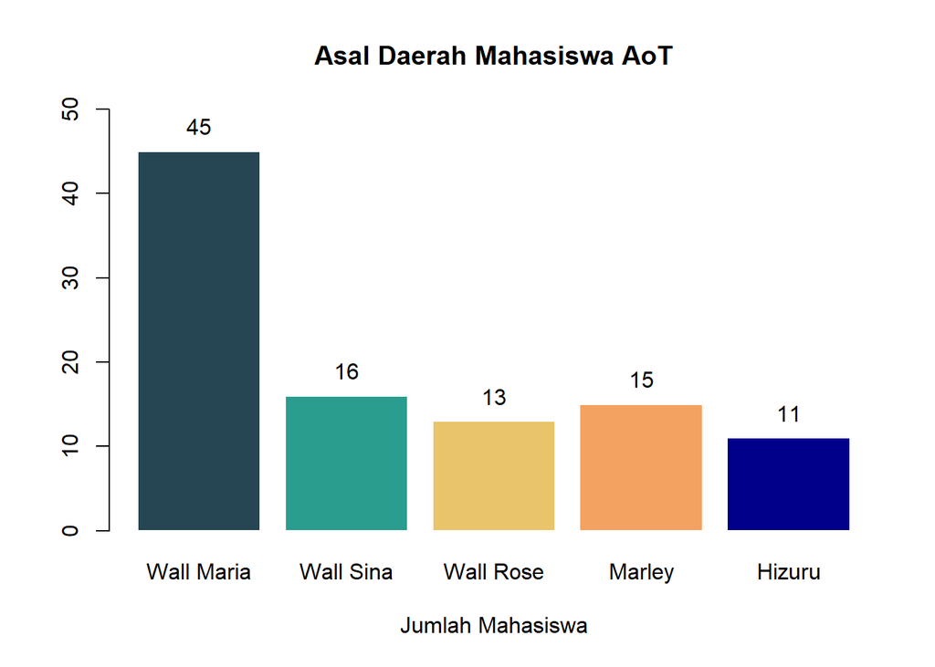

```r
bar = barplot(dfMahasiswa$Total.Mahasiswa,
        main="Asal Daerah Mahasiswa AoT",
        names = dfMahasiswa$Daerah,
        col = c("#264653","#2a9d8f","#e9c46a","#f4a261",'darkblue'),
        border = FALSE,
        ylim = range(0, 50),

        xlab="Jumlah Mahasiswa")
text(x = bar,
     y = dfMahasiswa$Total.Mahasiswa+3,
     labels = dfMahasiswa$Total.Mahasiswa,
)
```

### Stacked Bar Plot

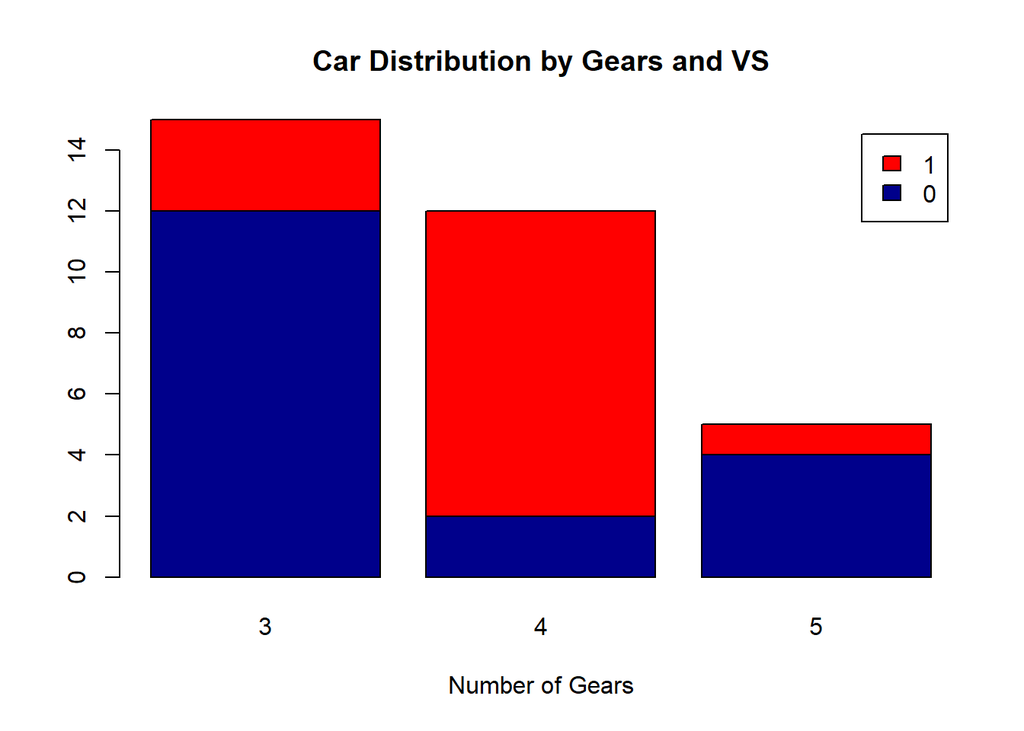

```r
# Stacked Bar Plot with Colors and Legend
counts <- table(mtcars$vs, mtcars$gear)
barplot(counts, main="Car Distribution by Gears and VS",
  xlab="Number of Gears", col=c("darkblue","red"),
  legend = rownames(counts))
```

### Group Bar Plot

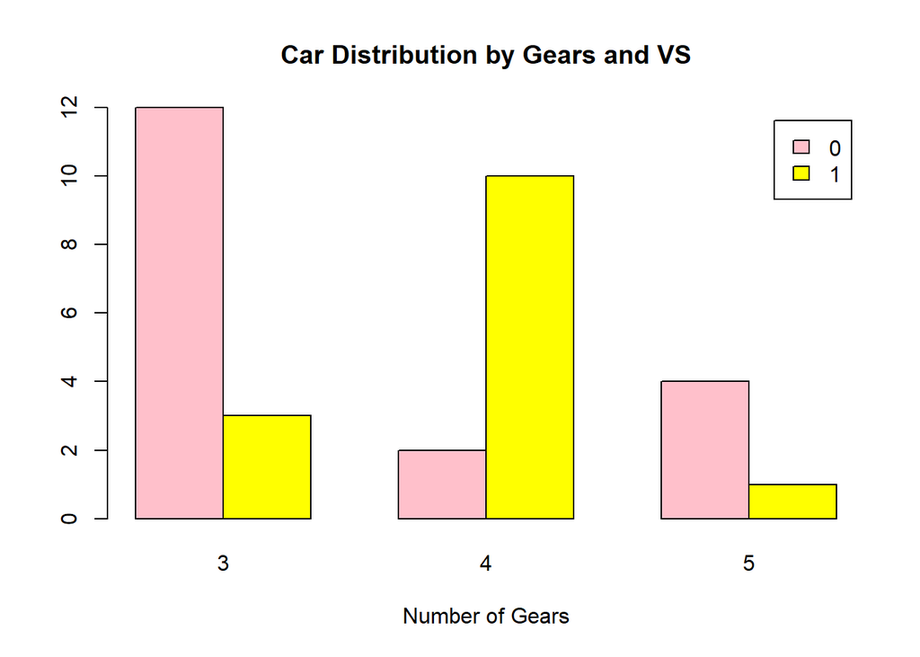

```r
# Stacked Bar Plot with Colors and Legend
# Grouped Bar Plot
counts <- table(mtcars$vs, mtcars$gear)
barplot(counts, main="Car Distribution by Gears and VS",
  xlab="Number of Gears", col=c("pink","yellow"),
  legend = rownames(counts), beside=TRUE)
```

### Group Bar Plot Import Data

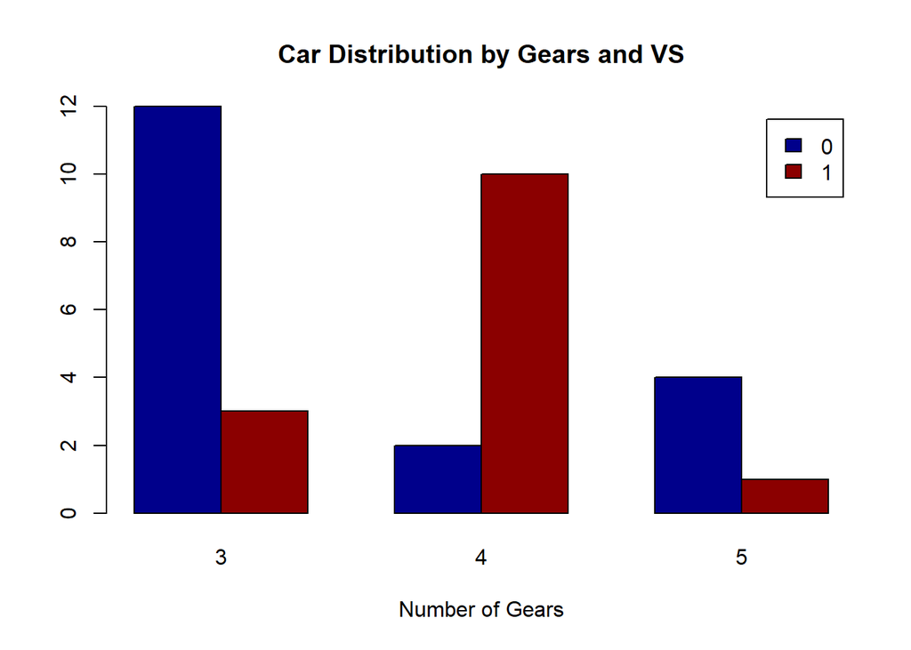

```r
# Stacked Bar Plot with Colors and Legend
# Grouped Bar Plot
employee <- read.csv("mtcars.csv", TRUE, sep = ",")
counts <- table(mtcars$vs, mtcars$gear)
barplot(counts, main="Car Distribution by Gears and VS",
  xlab="Number of Gears", col=c("darkblue","darkred"),
  legend = rownames(counts), beside=TRUE)
```

## 3. Histogram

*Simple Histogram with Customize Color*

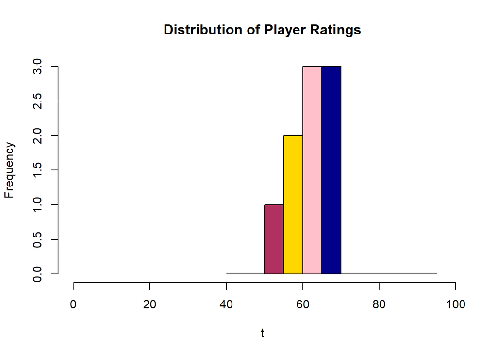

```r
t<- c(69,68,67,65,65,62,59,59,54)
hist(t, main="Distribution of Player Ratings",xlim = c(0,99),
       breaks=c(seq(40,99,5)), col = c("pink", "darkblue", "maroon", "gold"))
```

*Histogram with added parameters*

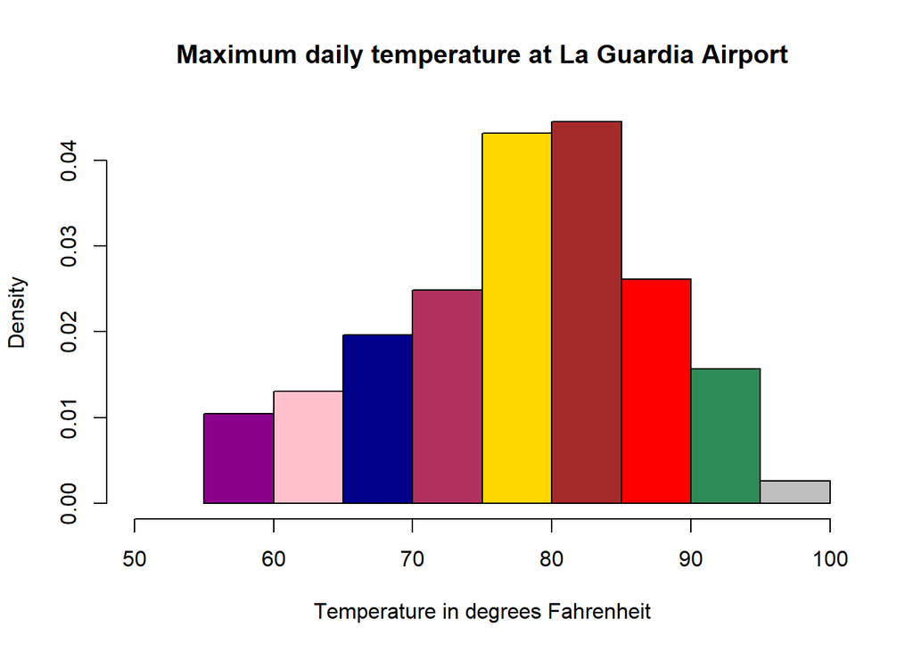

```r
Temperature <- airquality$Temp
# histogram with added parameters
hist(Temperature,
     main="Maximum daily temperature at La Guardia Airport",
     xlab="Temperature in degrees Fahrenheit",
     xlim=c(50,100),
     col= c("darkmagenta","pink", "darkblue", "maroon", "gold","brown", "red", "Seagreen", "grey"),
     freq=FALSE
)
```

## 4. Stem and Leaf Plot in R

In R, stem and leaf plots(also known as stem and leaf diagrams) of any quantitative variable, say x, is a textual graph that is used to classify the data items in order of their most significant numeric digits. The term stem and leaf is so because the plot is given in a tabular format where each numeric value or data item is split into a stem i.e. the first digit and a leaf i.e. the last digit. For example, suppose the input data is 94. Then 9 will be the stem and 4 will be the leaf.

**Syntax:**

```
stem(number, scale = 1, width = 80, atom = 1e-08)
```

Parameters: **number**: the data on which we want to draw the stem and leaf plot [either a numeric vector or a list of numeric vectors] **scale**: the scale we want to use for our plot **width**: the desired width for our plot [it is 80 by default] **atom**: tolerance

**Creating a Stem and Leaf Plot in R** Here let’s use the ChickWeight data set where considering the weight. At first let’s see how to use the stem and leaf plot in a simpler manner by using stem().

Pakai Data Bawaan R yaitu ChickWeight

```r
head(ChickWeight)
```

```
##   weight Time Chick Diet
## 1     42    0     1    1
## 2     51    2     1    1
## 3     59    4     1    1
## 4     64    6     1    1
## 5     76    8     1    1
## 6     93   10     1    1
```

```r
# R program to illustrate
# Stem and Leaf Plot

# using stem()
stem(ChickWeight$weight)
```

```
##
##   The decimal point is 1 digit(s) to the right of the |
##
##    2 | 599999999
##    4 | 00000111111111111111111112222222222222223333456678888888899999999999+38
##    6 | 00111111122222222333334444455555666677777888888900111111222222333334+8
##    8 | 00112223344444455555566777788999990001223333566666788888889
##   10 | 0000111122233333334566667778889901122223445555667789
##   12 | 00002223333344445555667788890113444555566788889
##   14 | 11123444455556666677788890011234444555666777777789
##   16 | 00002233334444466788990000134445555789
##   18 | 12244444555677782225677778889999
##   20 | 0123444555557900245578
##   22 | 0012357701123344556788
##   24 | 08001699
##   26 | 12344569259
##   28 | 01780145
##   30 | 355798
##   32 | 12712
##   34 | 1
##   36 | 13
```

**Explanation:** Here $ sign is used in the command to extract the data form the list used. The stem() command extracts the numeric data and splits them into two parts namely, the stem and leaf. The left side shows the most significant digit while the last digit is shown on the right hand side. For better readability the numbers having same stem value are merged together.

#### Using the scale argument

Now let’s see the same stem and leaf plot after rescaling our desired plot. To rescale the plot we need to use the scale argument inside the stem() function.

```r
# R program to illustrate
# Stem and Leaf Plot

# Drawing Stem and Leaf Plot after rescaling
stem(ChickWeight$weight, scale = 5)
```

```
##
##   The decimal point is 1 digit(s) to the right of the |
##
##    3 | 599999999
##    4 | 000001111111111111111111122222222222222233334
##    4 | 5667888888889999999999999
##    5 | 00000011111111222233333444
##    5 | 5555566667778888899999
##    6 | 001111111222222223333344444
##    6 | 555556666777778888889
##    7 | 001111112222223333344444444
##    7 | 6667778889999
##    8 | 001122233444444
##    8 | 5555556677778899999
##    9 | 0001223333
```

[output cut: 56 more lines]

**Explanation:** After changing the scaling, the distribution of data has changed horizontally. Again here the stems are on the left side and the leaves are on the right side.

#### Using the width argument

On using width argument in the stem() function one can change the width of the plot into a desired plot.

```r
# R program to illustrate
# Stem and Leaf Plot

# Drawing Stem and Leaf Plot by changing the width
stem(ChickWeight$weight, width = 100)
```

```
##
##   The decimal point is 1 digit(s) to the right of the |
##
##    2 | 599999999
##    4 | 0000011111111111111111111222222222222222333345667888888889999999999999000000111111112222+18
##    6 | 0011111112222222233333444445555566667777788888890011111122222233333444444446667778889999
##    8 | 00112223344444455555566777788999990001223333566666788888889
##   10 | 0000111122233333334566667778889901122223445555667789
##   12 | 00002223333344445555667788890113444555566788889
##   14 | 11123444455556666677788890011234444555666777777789
##   16 | 00002233334444466788990000134445555789
##   18 | 12244444555677782225677778889999
##   20 | 0123444555557900245578
##   22 | 0012357701123344556788
##   24 | 08001699
##   26 | 12344569259
##   28 | 01780145
##   30 | 355798
##   32 | 12712
##   34 | 1
##   36 | 13
```

**Explanation:** As the width is changed to 100 from 80, the distribution of data has also changed. Here the left side of the chart shows the stem while the leaves are on the right-hand side of the chart.

**Usage of Stem and Leaf plot:**

1.The stem and leaf plot is very useful for displaying the shape and relative density of data, hence giving the reader or customer a quick overview of the kind of distribution.

2. Most of the times they can retain the raw data with quite perfect integrity.
3. A very useful method for highlighting the outliers and also for finding the mode.